# Wisconsin Obesity

Bret Larget

## Obesity Overview

### Data Files

- The Wisconsin obesity data is stored in two Excel workbooks, one for females and one for males.
- The data for each sex is split across five sheets based on age ranges.
- Each spread sheet has a row for each zip code and seven columns of data (three of which are derived) from counts in the other three.
- There is substantial missing data as counts are not reported if they are low by several criteria.

### Long format versus wide format

- There are two primary *conceptual* ways to read in and combine this data.
- To combine the data in **long format**, the 10 data sets are read in and stacked on top of one another, adding columns for sex and age range.
- In long format, a single *case* has the information for a ZIP code/sex/age range combination.
- Alternatively, in **wide format**, we would stick together the data sets horizontally, maintaining a single row per ZIP code.
- In wide format, we would need to relabel the columns so that each column name would also include the sex/age range from which it arose.
- This file will demonstrate reading the data into long format and then show how to reformat this into wide format as needed.

### Read, Reformat, and Reshape Obesity Data

- To read data from one sheet into a single data frame we could do something like the following.

```r
male_05_17 =  read_excel(
  "../../data/Obesity+Prevalence+by+ZIP+Code+and+Age+Group,+Males.xlsx",
  sheet=3, skip=5, na=".")

str(male_05_17)
```

```
## tibble [774 × 7] (S3: tbl_df/tbl/data.frame)
##  $ ZIP
## Code                                    : num [1:774] 53001 53002 53003 53004 53005 ...
##  $ Obesity
## Prevalence (%)                      : num [1:774] NA 15.5 NA NA NA NA NA 14.4 NA 11.7 ...
##  $ Number of
## Patients with
## Obesity          : num [1:774] NA 11 NA NA NA NA NA 29 NA 52 ...
##  $ Number of
## Patients with Valid
## BMI        : num [1:774] NA 71 NA NA NA NA NA 201 NA 446 ...
##  $ 95% Confidence
## Interval for Percent
## Obese: chr [1:774] NA "( 8.9, 25.7)" NA NA ...
##  $ Percent of Population
## with Valid BMI (%)    : num [1:774] NA 33.6 NA NA NA NA NA 31.1 NA 25.5 ...
##  $ Population from US
## Census (2011-2015)       : num [1:774] 164 211 5 400 1782 ...
```

- The data for males, aged 5 to 17, is on sheet 3 of the given file.
- The first five lines of this file contain title information, line six has the column names, and data comes below this.
- The data is actually in columns B through H, but `read_excel()` is smart enough by default to ignore empty column A.
- Take a peek at this data.

```r
head(male_05_17)
```

```
## # A tibble: 6 × 7
##   `ZIP\r\nCode` `Obesity\r\nPrevalence (%)` `Number of\r\nPat… `Number of\r\nPa…
##           <dbl>                       <dbl>              <dbl>             <dbl>
## 1         53001                        NA                   NA                NA
## 2         53002                        15.5                 11                71
## 3         53003                        NA                   NA                NA
## 4         53004                        NA                   NA                NA
## 5         53005                        NA                   NA                NA
## 6         53006                        NA                   NA                NA
## # … with 3 more variables: 95% Confidence
## Interval for Percent
## Obese <chr>,
## #   Percent of Population
## with Valid BMI (%) <dbl>,
## #   Population from US
## Census (2011-2015) <dbl>
```

- What is clear is that the given column names are not convenient and there is considerable missing data.
- Here is some code that selects the columns with raw data (we can always re-derive the others if desired, and this is safer than trusting it is accurate) and then renames the columns.
- This code uses `select()` and `rename()` from `dplyr` along with the select helper functions `starts_with()` and `ends_with()` to avoid typing the long variable names provided.
- Furthermore, we use `mutate()` to add columns `sex` and `age` which contain the corresponding values for this part of the data.

```r
male_05_17 = male_05_17 %>%
  select(starts_with("ZIP"),
         starts_with("Number"),
         starts_with("Population")) %>%
  rename(zip = starts_with("ZIP"),
         obese = ends_with("Obesity"),
         n = ends_with("BMI"),
         pop = starts_with("Population")) %>%
  mutate(sex = "male") %>%
  mutate(age = "5-17")

head(male_05_17)
```

```
## # A tibble: 6 × 6
##     zip obese     n   pop sex   age
##   <dbl> <dbl> <dbl> <dbl> <chr> <chr>
## 1 53001    NA    NA   164 male  5-17
## 2 53002    11    71   211 male  5-17
## 3 53003    NA    NA     5 male  5-17
## 4 53004    NA    NA   400 male  5-17
## 5 53005    NA    NA  1782 male  5-17
## 6 53006    NA    NA   176 male  5-17
```

```r
rm(male_05_17)
```

#### Combining

- To finish creating the data set in long format, we could copy/paste/edit the previous code for all 10 sheets and then use `bind_rows()` to combine into a single data frame.
- A better way, however, is to **write a function** for the repeated elements of code.
- This results in code that is:
  - more concise,
  - easier to read,
  - easier to edit,
  - and more clear.
- The cost is a bit of new syntax where we introduce the **`for()` loop.**
- The only parts of the previous code that vary when we read different sheets are: the file name, the number of the sheet, and the values for `sex` and `age`.
- The next function `read_and_format()` takes as arguments the name of the Excel file, a string which is one of “female” or “male”, and an integer `i` from 1 to 5 which indicates which age range we are reading.
- For example, age range 1 is from 5–17 and is on sheet 3 for both the male and female workbooks.

```r
## file is a string with filename
## sex_string is either "female" or "male"
## i is a number from 1 to 5
read_and_format = function(file, sex_string, i)
{
  age_values = c("05-17","18-34","35-54","55-74","75+")

  temp = read_excel(file, sheet=i+2, skip=5, na=".") %>%
    select(starts_with("ZIP"),
         starts_with("Number"),
         starts_with("Population")) %>%
    rename(zip = starts_with("ZIP"),
           obese = ends_with("Obesity"),
           n = ends_with("BMI"),
           pop = starts_with("Population")) %>%
    mutate(sex = sex_string) %>%
    mutate(age = age_values[i])

  return( temp )
}
```

```r
## test the function
male_05_17 = read_and_format("../../data/Obesity+Prevalence+by+ZIP+Code+and+Age+Group,+Males.xlsx",
                             "male", 1)
male_18_34 = read_and_format("../../data/Obesity+Prevalence+by+ZIP+Code+and+Age+Group,+Males.xlsx",
                             "male", 2)
```

### For Loops

- To repeatedly call the same function for different values, a *for loop* is very useful.
- Here is a simple example of a for loop in R to add up the numbers from 4 to 10.

```r
## initialize a container to keep the sum
my_sum = 0

## i is an index variable which will take on the values from 4 to 10 in the loop
## We print the values of i and my_sum at each stage so you can see how they change as the loop executes
## cat() concatenates objects into a single string and here writes to the console
## The symbol \n refers to a carriage return (new line)

for ( i in 4:10 )
{
  cat("i =", i, "\n")
  my_sum = my_sum + i
  cat("my_sum =", my_sum, "\n")
}
```

```
## i = 4
## my_sum = 4
## i = 5
## my_sum = 9
## i = 6
## my_sum = 15
## i = 7
## my_sum = 22
## i = 8
## my_sum = 30
## i = 9
## my_sum = 39
## i = 10
## my_sum = 49
```

```r
## Show the final value
my_sum
```

```
## [1] 49
```

#### Double for loop

- It is possible to write a *double for loop*
- There are two separate indices
- The inner loop repeats in its entirety for each single pass through the outer loop.
- Here is an example.

```r
my_sum = 0
for ( i in 1:5 )
{
  for ( j in 1:3 )
  {
    my_sum = my_sum + i*j
    cat("i =", i, ", j =", j, ", add", i*j, "and get", my_sum, "\n")
  }
}
```

```
## i = 1 , j = 1 , add 1 and get 1
## i = 1 , j = 2 , add 2 and get 3
## i = 1 , j = 3 , add 3 and get 6
## i = 2 , j = 1 , add 2 and get 8
## i = 2 , j = 2 , add 4 and get 12
## i = 2 , j = 3 , add 6 and get 18
## i = 3 , j = 1 , add 3 and get 21
## i = 3 , j = 2 , add 6 and get 27
## i = 3 , j = 3 , add 9 and get 36
## i = 4 , j = 1 , add 4 and get 40
## i = 4 , j = 2 , add 8 and get 48
## i = 4 , j = 3 , add 12 and get 60
## i = 5 , j = 1 , add 5 and get 65
## i = 5 , j = 2 , add 10 and get 75
## i = 5 , j = 3 , add 15 and get 90
```

```r
my_sum
```

```
## [1] 90
```

### For loops to read the obesity data

- We write a second function which uses two nested for loops to read the data for all sexes and age ranges, combining the data sets as each new one is read in.
- The outer loop goes over the two sexes and the inner loop goes over the indices of the age ranges.
- The function creates an initial empty `tibble`.
- Each sheet is read into a temporary data frame which is then bound (using `bind_rows()`) to the initial one until the initial one has grown to be the complete data frame.
- Note that `bind_rows()` only works when the columns are compatible.

```r
read_obesity = function()
{
  ## Create an empty container to hold the data as we read it in
  obesity = tibble()
  ## vector of the two sexes
  sexes = c("female","male")
  ## the next several lines create a vector of length 2
  ## which has the two file names, #1 for female, #2 for male
  ## Use str_c() to combine the parts of the strings into a vector of strings part-wise
  files = str_c("../../data/",
                "Obesity+Prevalence+by+ZIP+Code+and+Age+Group,",
                c("+Females", "+Males"),
                ".xlsx")

  for ( s in 1:2 ) ## s is an index into files and sexes
  {
    for ( i in 1:5 ) ## i+3 is the sheet and i is an index into age
    {
      ## temporary object with a data from a single sheet
      temp = read_and_format(files[s],sexes[s],i)
      ## add the data we just read in to the combined data set
      obesity = bind_rows(obesity,temp)
    }
  }

  ## change zip from numerical to character
  obesity = obesity %>%
    mutate(zip = as.character(zip))

  ## reorder the columns
  obesity = obesity %>%
    select(zip, sex, age, everything())

  return( obesity )
}
```

### Read and Save the Data

- Now call the function and save the obesity data.

```r
obesity = read_obesity()

head(obesity)
```

```
## # A tibble: 6 × 6
##   zip   sex    age   obese     n   pop
##   <chr> <chr>  <chr> <dbl> <dbl> <dbl>
## 1 53001 female 05-17    NA    NA   151
## 2 53002 female 05-17    11    78   172
## 3 53003 female 05-17    NA    NA     4
## 4 53004 female 05-17    NA    NA   325
## 5 53005 female 05-17    NA    NA  1882
## 6 53006 female 05-17    NA    NA   122
```

```r
dim(obesity)
```

```
## [1] 7740    6
```

```r
write_csv(obesity, "../../data/obesity.csv")
```

- The long format data has advantages for many purposes.
- We can easily add new columns, such as prevalence of obesity among sampled patients for each zip/sex/age combination, or the total estimated number of such people in the population.
- We can filter to select certain characteristics (only males, only one age group).
- We can also aggregate (sum over zip codes, sexes, or whatever we want).

### Understanding the Data

- There is one row (case) per zip code, sex, and age cohort.
- `zip`: the zip code
  - there are 774 zip codes from Wisconsin represented in the data set
  - we will use this data as a key to other data sets
- `sex`: either *male* or *female*
  - we will be interested to see if there are obesity differences between the sexes
- `age`: is an age range with possible values *5-17*, *18-34*, *35-54*, *55-74*, and *75+*
  - we will be interested to examine differences by age
  - note that we have not obesity data on individuals age four years or younger
- `obese`: the number of obese individuals in the *sample*
- `n`: the sample size (people whose sex, age, BMI, and obesity status were measured)
- `pop`: the population in that zip code of the total number of people of a given age and sex
- There is substantial missing data in the data set.

### Estimation

- We are interested in knowing things about all people in the state of Wisconsin
- We would like to know the obesity status for everyone in the population.
- However, we only have this information for a subset
- If we assume that the obesity proportion of unsampled people is the same as sampled people within each zip code, sex, and age range, we can *estimate* the numbers of obese and non-obese people in each.
- With these estimates of the population, we can aggregrate in various ways and make estimates at the state level.
- Add columns for the estimated number of obese and non-obese people in each row.

```r
obesity = obesity %>%
  mutate(obese_pop = pop * (obese/n),
         non_obese_pop = pop * (1 - obese/n))

head(obesity)
```

```
## # A tibble: 6 × 8
##   zip   sex    age   obese     n   pop obese_pop non_obese_pop
##   <chr> <chr>  <chr> <dbl> <dbl> <dbl>     <dbl>         <dbl>
## 1 53001 female 05-17    NA    NA   151      NA             NA
## 2 53002 female 05-17    11    78   172      24.3          148.
## 3 53003 female 05-17    NA    NA     4      NA             NA
## 4 53004 female 05-17    NA    NA   325      NA             NA
## 5 53005 female 05-17    NA    NA  1882      NA             NA
## 6 53006 female 05-17    NA    NA   122      NA             NA
```

### Questions

#### 1

> According to US Census Bureau estimates, the population of Wisconsin was about 5.76 million people in 2015. What is the total population of people represented in this data set? Why do these values disagree?

```r
prob1 = obesity %>%
  select(pop) %>%
  summarize(pop = sum(pop))

## Sum of populations in data set
prob1
```

```
## # A tibble: 1 × 1
##       pop
##     <dbl>
## 1 5397733
```

```r
## Wisconsin population
wi_pop = 5.76 * 10^6
wi_pop
```

```
## [1] 5760000
```

```r
## Difference
wi_pop - pull(prob1,pop)
```

```
## [1] 362267
```

#### Answer

- The data set does not include children aged 4 years and younger.

#### 2

> Calculate the total population within each zip code and store these 774 values in a new data frame. Make a box plot of these values. Calculate the minimum, lower quartile (0.25 quantile), the median, the upper quartile (0.75 quantile), and the maximum of these values.

#### Answer

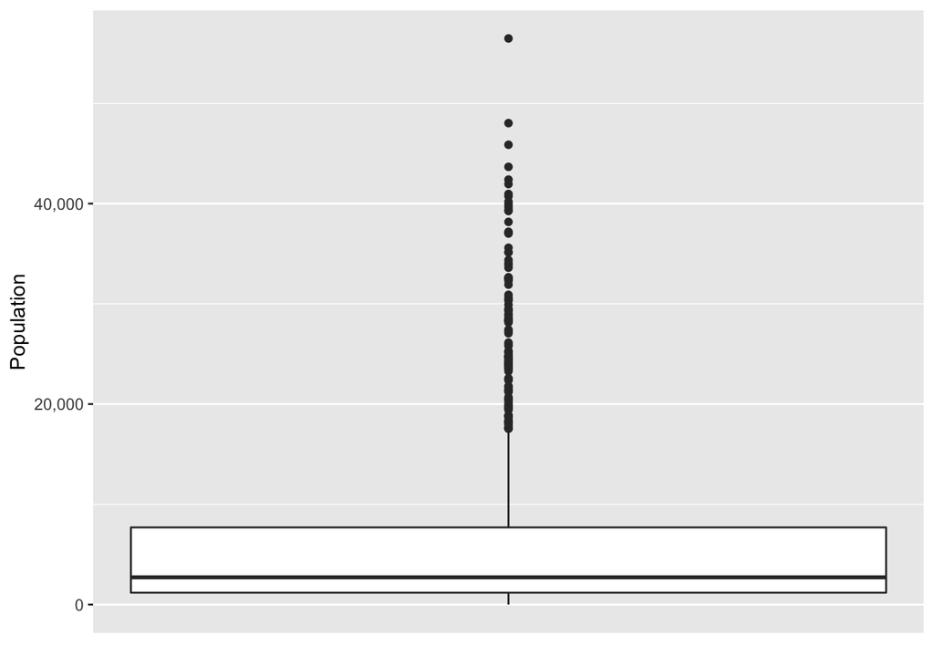

```r
## count total population by zip code
prob2 = obesity %>%
  select(zip, pop) %>%
  group_by(zip) %>%
  summarize(pop = sum(pop))

## box plot
ggplot(prob2, aes(x=0, y=pop)) +
  geom_boxplot() +
  xlab("") +
  ylab("Population") +
  scale_x_continuous(breaks = NULL, labels = NULL) +
  scale_y_continuous(label = comma)
```

```r
## quantiles
### short version using quantile()
prob2 %>%
  pull(pop) %>%
  quantile()
```

```
##       0%      25%      50%      75%     100%
##     0.00  1186.25  2717.00  7698.50 56472.00
```

```r
## explicit with summarize() in the tidyverse
prob2 %>%
  summarize(min = min(pop),
            q25 = quantile(pop, 0.25),
            median = median(pop),
            q75 = quantile(pop, 0.75),
            max = max(pop))
```

```
## # A tibble: 1 × 5
##     min   q25 median   q75   max
##   <dbl> <dbl>  <dbl> <dbl> <dbl>
## 1     0 1186.   2717 7698. 56472
```

- The data has a very strong right skew.
- There are a few highly populated zip codes.
- A typical zip code has just a few thousand people.

#### 3

> Estimate the overall proportion of obesity in Wisconsin. Calculate the total number of obese people in Wisconsin and divide by the total number of people in zip code / sex / age cohorts where there is an estimate of the number of obese people. (You will need to drop rows prior to making the calculation.) Express the value as a percentage rounded to one decimal place.

#### Answer

```r
prob3 = obesity %>%
  drop_na() %>%
  summarize(obese = sum(obese_pop),
            pop = sum(pop),
            obese_pct = 100*obese/pop)

prob3$obese_pct
```

```
## [1] 37.96828
```

#### 4

> Repeat the previous problem, but do so separately for females and males.

#### Answer

```r
prob4 = obesity %>%
  drop_na() %>%
  group_by(sex) %>%
  summarize(obese = sum(obese_pop),
            pop = sum(pop),
            obese_pct = 100*obese/pop)

prob4
```

```
## # A tibble: 2 × 4
##   sex      obese     pop obese_pct
##   <chr>    <dbl>   <dbl>     <dbl>
## 1 female 773815. 2073806      37.3
## 2 male   718203. 1855838      38.7
```